# Price Data Analysis

Pankaj Kumar , Karl Jurek, Shawn Jung

5/31/2019

## Introduction

Using the Modeling.csv file we created the following models:

Stepwise

LASSO

Final

to predict the cost of housing in the predictionData.csv file.

## Data Description

The modelingData.csv file contains properties sold between August 20, 2011 and June 30, 2015.

25471 observations / rows

292 variables / columns

The predictionData.csv file contains properties sold between July 2015 and May2016.

5000 observations / rows

291 variables / columns

## Data Cleaning / Wrangling

** Initial import of the the modelingData.csv and predictionData.csv required stringsAsFactors=F

** Converting Time Stamp from integer based to date format (yyyy-mm-dd)

** modeling_df=transform(modeling_df, timestamp=as.Date(timestamp, origin = “1899-12-30”))

** projection_df=transform(projection_df, timestamp=as.Date(timestamp, origin = “1899-12-30”))

### Build_year -

** 14965 transformed to 1965

** 1691 transformed to 1991

** 20052009 transformed to 2007

### Kitch_sq

** 2013 deleted due to being the same as the build_year

** 2014 deleted due to being the same as the build_year

** 1974 deleted due to being the same as the build_year

** 1970 deleted due to being larger than the entire square footage of the building

### State

33 transformed to 3

Removed all apostrophe / single quotes from sub_area

There are Deleted 7991 rows where the max_floor, material, build_year, num_room, kitch_sq, and state all had a value of NA.

Deleted 1791 rows where the life_sq, build_year, and state all had a value of NA.

Deleted 1038 rows where the life_sq and build_year had a value of NA. Deleted 261 rows where the life_sq and state had a value of NA. Deleted 232 rows where the build_year and state had a value of NA.

## EDA

### Univariate Analysis

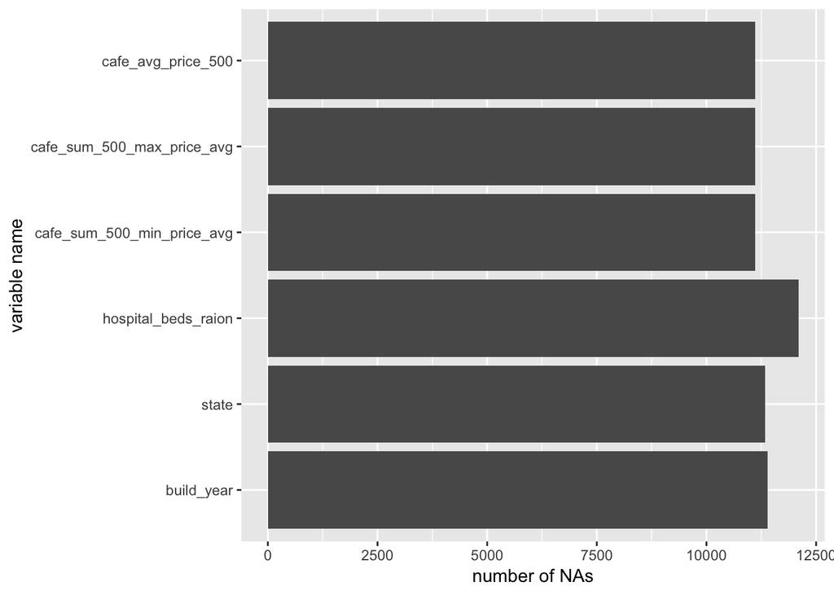

### Bivariate Analysis

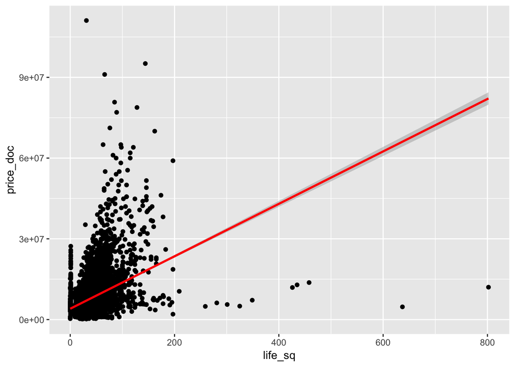

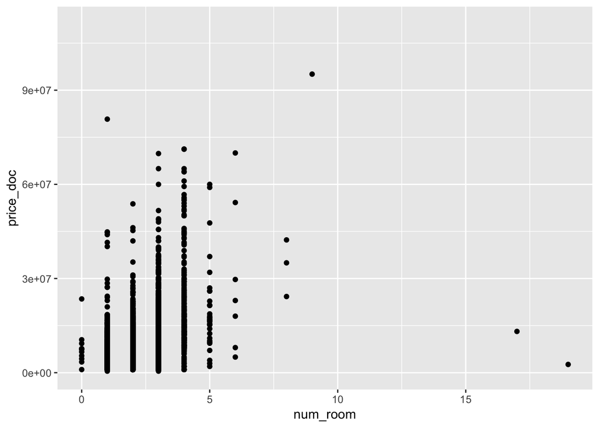

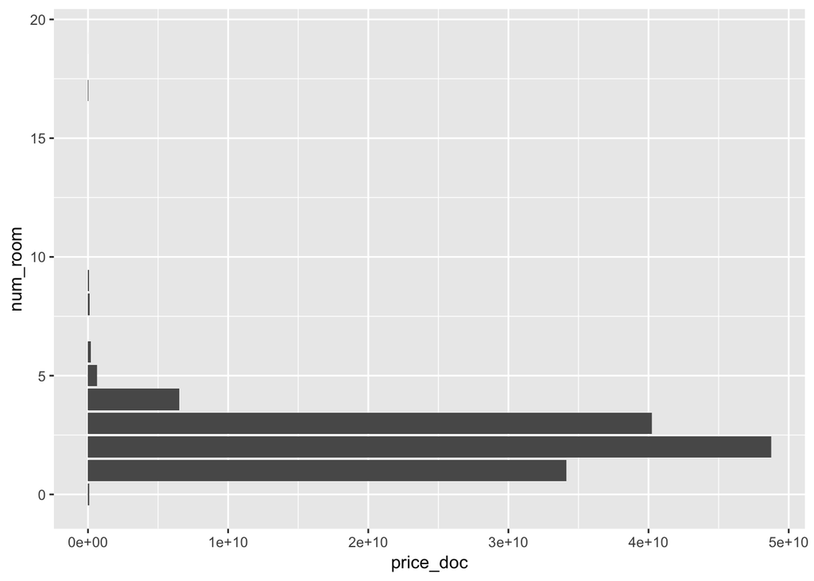

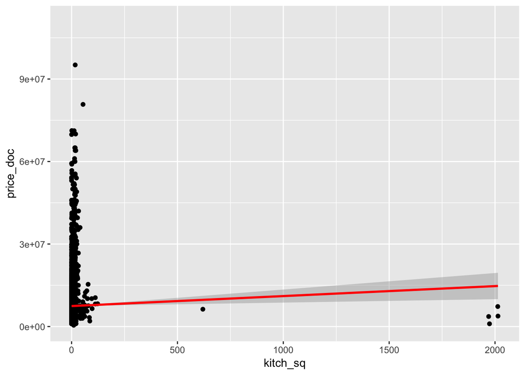

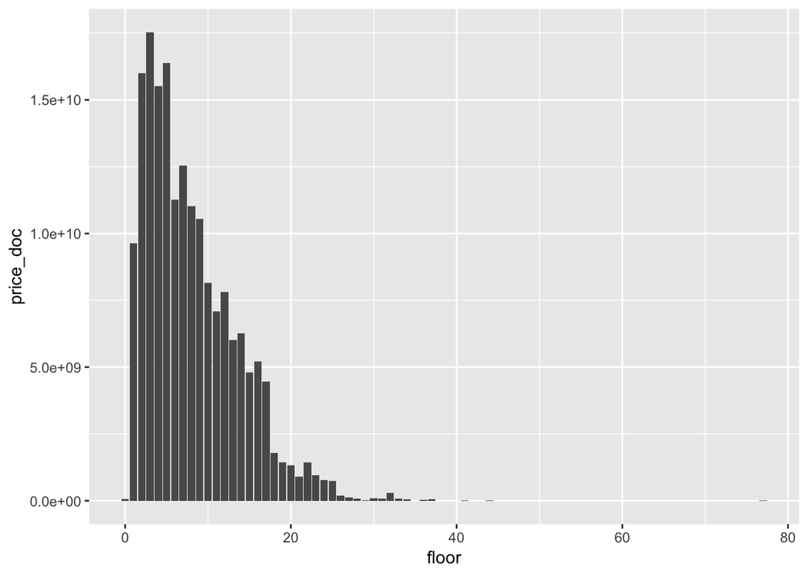

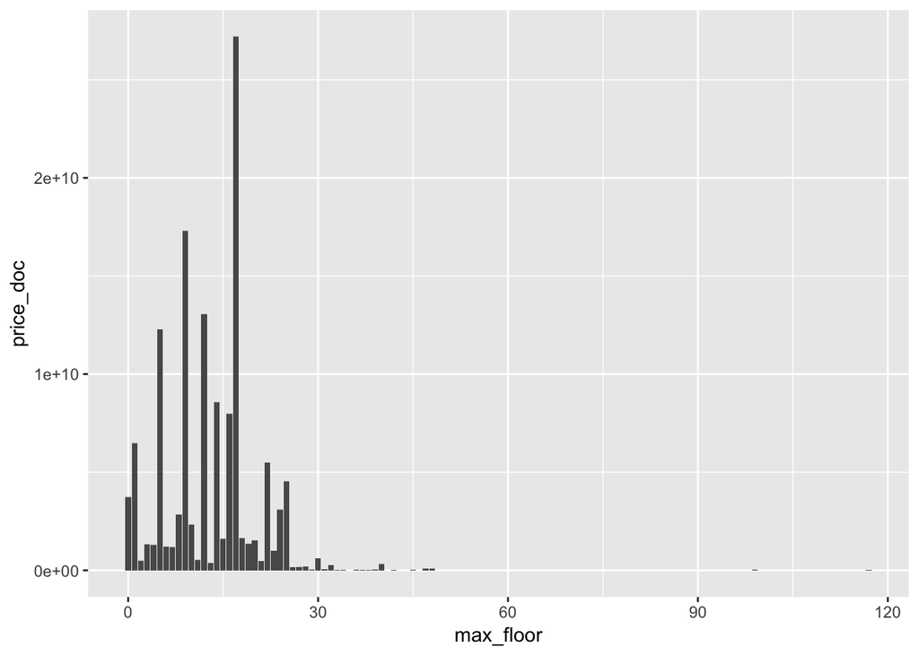

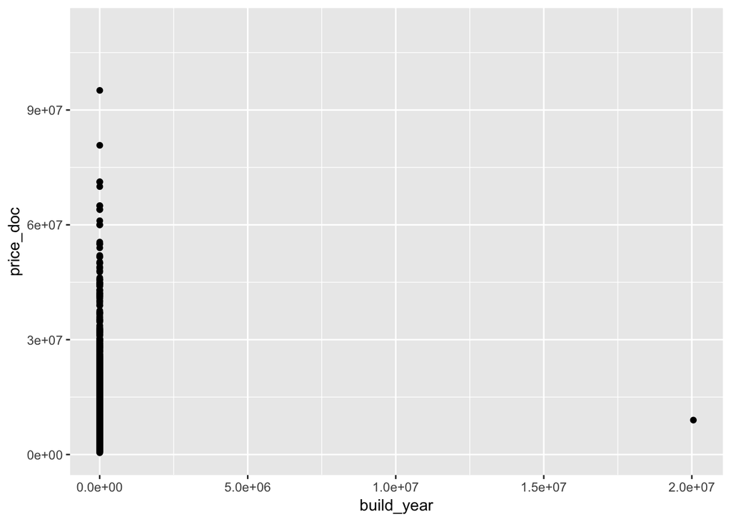

[figure not shown]

[figure not shown]

[figure not shown]

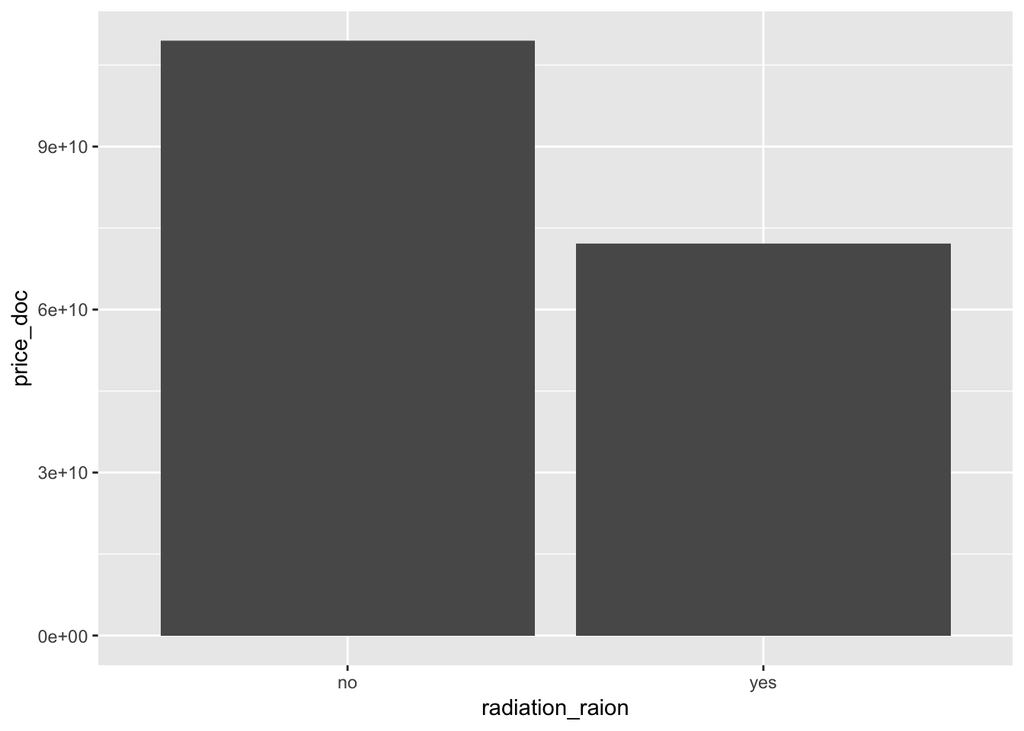

### Outliears

Outliers

Full_sq - 5326

## Modeling

[output not shown]